# TBCI 2021

Technical Exercises

Marcel Kappes[^1] & Nader Hotait[^2]

15 September, 2021

# First Exercise

## Exercise 2.1.6.3

### Task 1

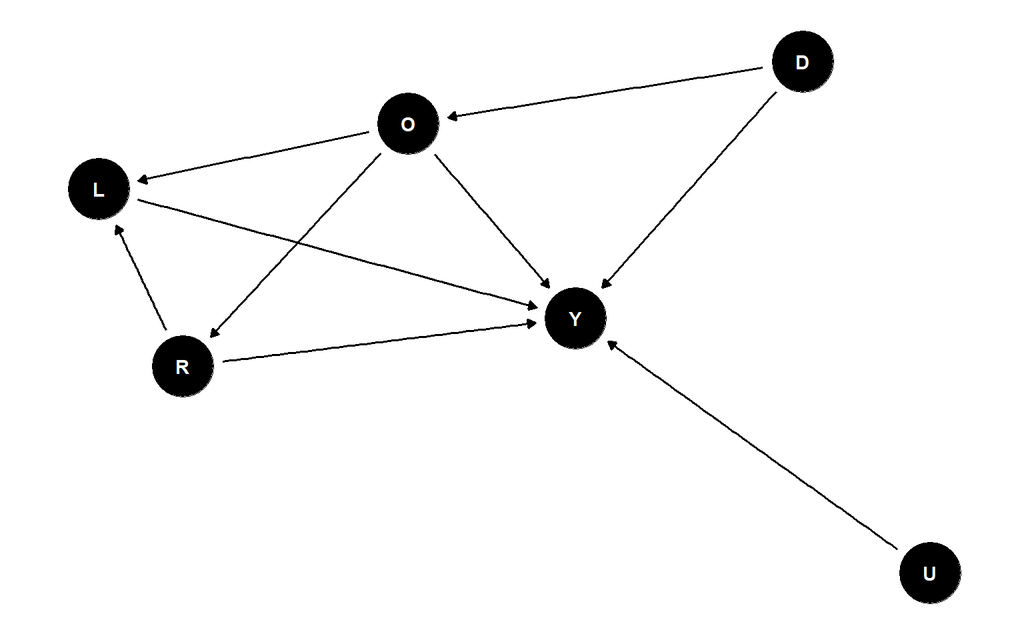

DAG

- Path 1: $R \to Y$, direct effect, front-door path
- Path 2: $R\to L \to Y$, mediator, front-door path
- Path 3: $R \gets O \to Y$, confounder, back-door path
- Path 4: $R \gets O \gets D \to Y$, confounder, back-door path
- Path 5.1: $R \gets O \to L \to Y$,confounder, back-door path
- *(Path 5.2: $R \to L \gets O \to Y$, confounder, back-door path)*

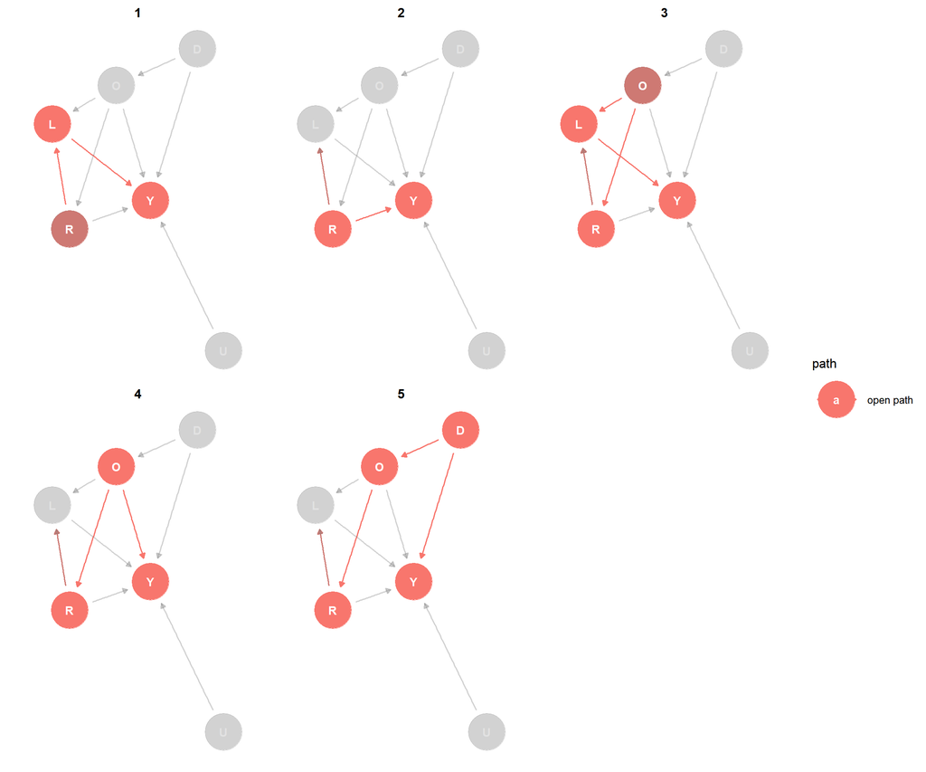

Open Paths

To identify the causal effect of $R$ on $Y$ we should close the back-door paths 3-5 by conditioning on $O$. After controlling for $O$, the path from $R$ to $Y$ through $D$ is blocked. Therefore, we do not need to control for it. In addition, we shall not control for the mediator/post-treatment variable $L$ as this would cause an overcontrol bias (Elwert 2013, 250).

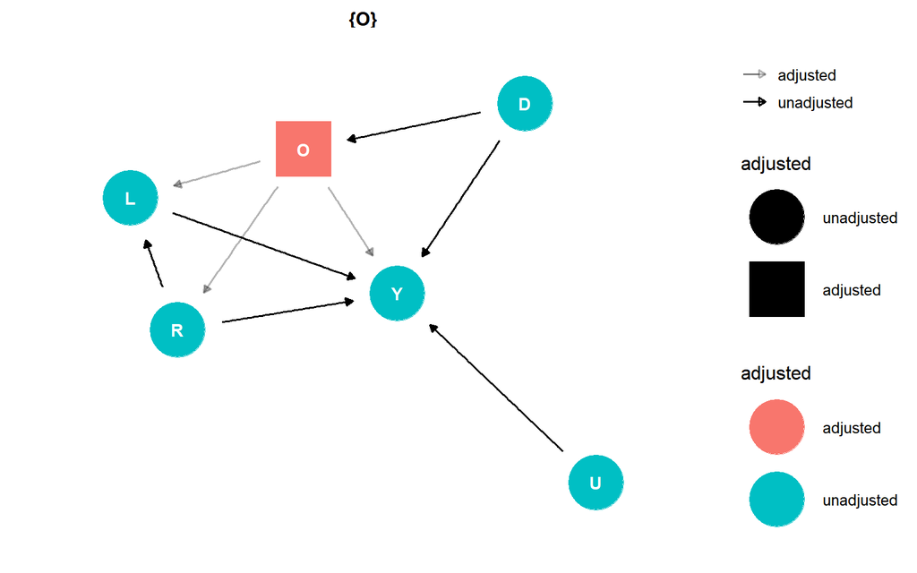

Adjusted DAG

### Task 2

If we cannot condition on $O$ the given back-door paths remain open and will bias the estimated effect of $R$ on $Y$ - the causal path would be therefore counfounded. Possible solutions could involve exchanging $O$ with an instrumental/proxy variable.

### Task 3

To incorporate Kitschelt and Rehm’s (2014) “weak theory” we have to add an arrow pointing from $U$ to $O$ in Figure 2.6.

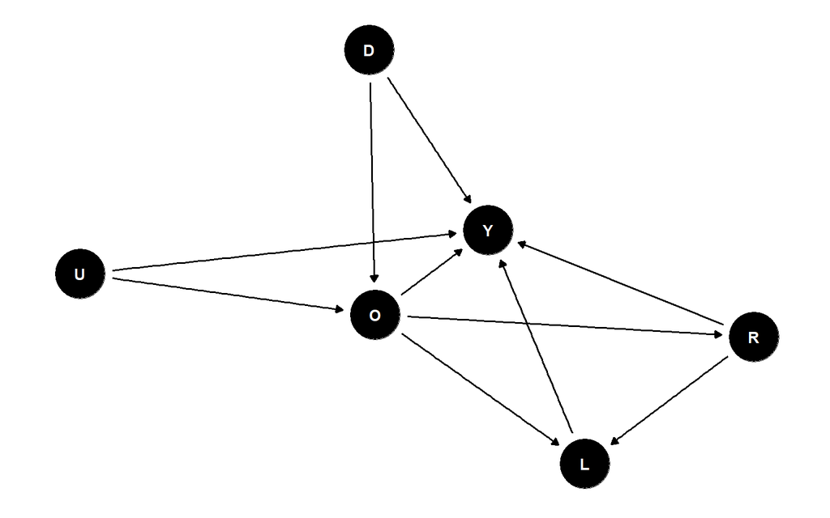

Iterated DAG

This change leads to a sixth possible path from $R$ to $Y$, being $R \gets O \gets U \to Y$ (confounder, back-door path). As $U$ cannot be measured, we can not condition for it.

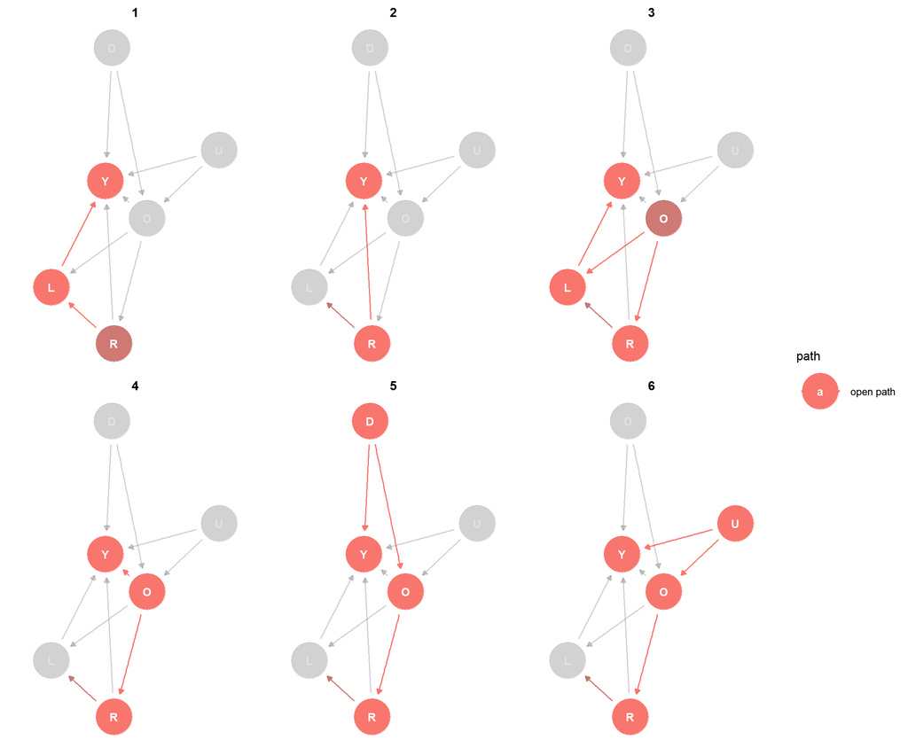

Open Paths after Iteration

However, as this new path is already blocked by controlling for $O$, it does not change our identification of the causal effect of $R$ on $Y$.

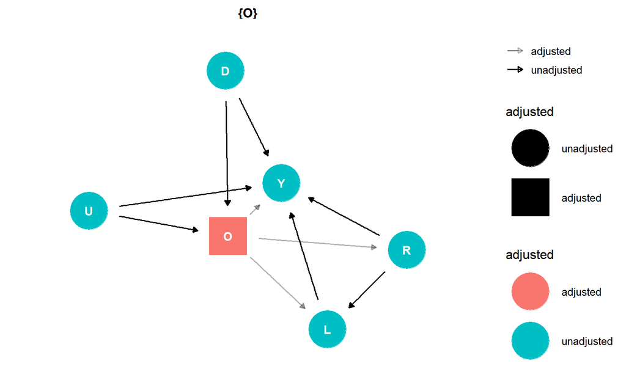

Iterated Adjusted DAG

## Exercise 2.3.4.2

### Setup

```r
# 1) Set seed
set.seed(20210009)

# 2) Define sampleize
n_students <- 200L

# 3) Simulate potential outcomes under the control
Y0 <- runif(n_students, min = 10, max = 90)

# 4) Simulate heterogenous treatment effects without truncation
tau_raw <- dplyr::case_when(
Y0 <= 30 ~ runif(n_students, 0, 10),
Y0 >= 80 ~ runif(n_students, 0, 20),
TRUE ~ runif(n_students, 0, 50)
)

# 5) Derive potential outcomes under the treatment without truncation
Y1_raw <- Y0 + tau_raw

# 6) Truncate (top-code) potential outcomes under the treatment
Y1 <- ifelse(Y1_raw >= 100, 100, Y1_raw)

# 7) Get treatment effects based on truncated potential outcomes
tau <- Y1 - Y0

# 8) Define names and covariates, collect everything in a tibble
student_data <- tibble(
randomNames::randomNames(
n_students,
which.names = "first",
return.complete.data = TRUE
),
Y0 = Y0,
Y1 = Y1,
tau = tau
)

# 9) Print tibble
student_data
```

```
## # A tibble: 200 x 6
##    gender ethnicity first_name    Y0    Y1   tau
##     <int>     <int> <chr>      <dbl> <dbl> <dbl>
##  1      1         4 Esperanza   24.6  27.0  2.38
##  2      1         1 Jamie Lee   83.4 100   16.6
##  3      0         4 Gustavo     30.4  79.7 49.3
##  4      1         2 Anchal      76.5 100   23.5
##  5      1         4 America     12.4  20.2  7.83
##  6      1         2 Vidushi     27.0  34.4  7.47
##  7      1         4 Tania       67.9 100   32.1
##  8      1         5 Maggie      17.5  20.5  2.96
##  9      1         6 Saamiqa     87.5 100   12.5
## 10      0         4 Leonardo    58.6  85.5 26.8
## # ... with 190 more rows
```

```r
# 10) Add probability vectors, treatment indicators & outcome vectors
student_data <- student_data %>%
mutate(
pi_r = 0.5,
D_r = rbinom(n_students, size = 1, prob = pi_r),
Y_obs_r = dplyr::if_else(D_r == 1, Y1, Y0),
pi_s = pnorm(scale(Y0) + rnorm(n_students, 0 , .75)),
D_s = rbinom(n_students, size = 1, prob = pi_s),
Y_obs_s = dplyr::if_else(D_s == 1, Y1, Y0)
)

## 11) Display again
DT::datatable(student_data)
```

|  | gender | ethnicity | first_name | Y0 | Y1 | tau | pi_r | D_r | Y_obs_r | pi_s | D_s | Y_obs_s |
| --- | --- | --- | --- | --- | --- | --- | --- | --- | --- | --- | --- | --- |
| 1 | 1 | 4 | Esperanza | 24.6371309272945 | 27.0197137771174 | 2.38258284982294 | 0.5 | 1 | 27.0197137771174 | [0.0312526242644055] | 0 | 24.6371309272945 |
| 2 | 1 | 1 | Jamie Lee | 83.3708661422133 | 100 | 16.6291338577867 | 0.5 | 1 | 100 | [0.974273122255447] | 1 | 100 |
| 3 | 0 | 4 | Gustavo | 30.3875803388655 | 79.6806014631875 | 49.293021124322 | 0.5 | 0 | 30.3875803388655 | [0.472140210936082] | 0 | 30.3875803388655 |
| 4 | 1 | 2 | Anchal | 76.4517079293728 | 100 | 23.5482920706272 | 0.5 | 0 | 76.4517079293728 | [0.847354765014384] | 1 | 100 |
| 5 | 1 | 4 | America | 12.3692446574569 | 20.2030018926598 | 7.83375723520294 | 0.5 | 0 | 12.3692446574569 | [0.258679284598337] | 1 | 20.2030018926598 |
| 6 | 1 | 2 | Vidushi | 26.9541891478002 | 34.425614872016 | 7.47142572421581 | 0.5 | 1 | 34.425614872016 | [0.108573355364004] | 0 | 26.9541891478002 |
| 7 | 1 | 4 | Tania | 67.9080892540514 | 100 | 32.0919107459486 | 0.5 | 0 | 67.9080892540514 | [0.907044068055552] | 0 | 67.9080892540514 |
| 8 | 1 | 5 | Maggie | 17.5120574422181 | 20.4737027268857 | 2.96164528466761 | 0.5 | 1 | 20.4737027268857 | [0.0742915563417438] | 0 | 17.5120574422181 |
| 9 | 1 | 6 | Saamiqa | 87.4866697005928 | 100 | 12.5133302994072 | 0.5 | 1 | 100 | [0.872248433410992] | 1 | 100 |
| 10 | 0 | 4 | Leonardo | 58.6389483511448 | 85.4615581664257 | 26.8226098152809 | 0.5 | 0 | 58.6389483511448 | [0.822977073943495] | 1 | 85.4615581664257 |

[output cut: 190 more lines]

### Task 1

**SUMMARY: Potential Outcomes and Random Assignment Groups tend to be independent. The opposite is true for Self-selection Assignment Groups**

**Creating a function to ease the work (Chi² test mostly not reliable)**

```r
ind_test <- function(y,x){
  cor <- cor.test(y,x)
  cor.p <- cor[["p.value"]]
  cor.b <- cor[["estimate"]][["cor"]]
  reg <- glm(x ~ y, family = "binomial")
  reg.p <- summary(reg)$coefficients[2,"Pr(>|z|)"]
  reg.b <- summary(reg)[["coefficients"]][2,1]
  chi <-chisq.test(table(y,x))
  chi.p <- chi[["p.value"]]
  chi.b <- NA
  method <- bind_rows(data.frame(c("Correlation Between Paired Samples", "ATE (Logistic Regression)", "Chi² Test")))
  pValue <- bind_rows(data.frame(c(cor.p, reg.p, chi.p)))
  beta <- bind_rows(data.frame(c(cor.b, reg.b, chi.b)))
  df <- bind_cols(method,pValue,beta)
  knitr::kable(df, caption = "Test of independence",
               col.names = c("Method", "p-Value", "$\\beta$"))
}
```

**Potential outcome under control $Y_0$ & Random Assignment $D_r$ = Independent ($p-Value > 0.05$)**

```r
ind_test(student_data$Y0,student_data$D_r)
```

Test of independence

| Method | p-Value | $\beta$ |
| --- | --- | --- |
| Correlation Between Paired Samples | 0.6571366 | -0.0315764 |
| ATE (Logistic Regression) | 0.6552889 | -0.0027483 |
| Chi² Test | 0.4667457 | NA |

**Potential outcome under control $Y_0$ & Self-selection Assignment $D_s$ = Not Independent ($p-Value < 0.05$)**

```r
ind_test(student_data$Y0,student_data$D_s)
```

Test of independence

| Method | p-Value | $\beta$ |
| --- | --- | --- |
| Correlation Between Paired Samples | 0.0000000 | 0.5048515 |
| ATE (Logistic Regression) | 0.0000000 | 0.0519244 |
| Chi² Test | 0.4667457 | NA |

**Potential outcome under treatment $Y_1$ & Random Assignment $D_r$ = Independent ($p-Value > 0.05$)**

```r
ind_test(student_data$Y1,student_data$D_r)
```

Test of independence

| Method | p-Value | $\beta$ |
| --- | --- | --- |
| Correlation Between Paired Samples | 0.3604227 | -0.0650082 |
| ATE (Logistic Regression) | 0.3584876 | -0.0045218 |
| Chi² Test | 0.4732913 | NA |

**Potential outcome under treatment $Y_1$ & Self-selection Assignment $D_s$ = Not Independent ($p-Value < 0.05$)**

```r
ind_test(student_data$Y1,student_data$D_s)
```

Test of independence

| Method | p-Value | $\beta$ |
| --- | --- | --- |
| Correlation Between Paired Samples | 0.0000000 | 0.4955186 |
| ATE (Logistic Regression) | 0.0000000 | 0.0399110 |
| Chi² Test | 0.1714852 | NA |

### Task 2

**Assignment $D_r | D_s$ & $Gender$ = Both Independent ($p-Value > 0.05$)**

```r
ind_test(student_data$gender,student_data$D_r)
```

Test of independence

| Method | p-Value | $\beta$ |
| --- | --- | --- |
| Correlation Between Paired Samples | 0.9164485 | 0.0074648 |
| ATE (Logistic Regression) | 0.9159243 | 0.0301203 |
| Chi² Test | 1.0000000 | NA |

```r
ind_test(student_data$gender,student_data$D_s)
```

Test of independence

| Method | p-Value | $\beta$ |
| --- | --- | --- |
| Correlation Between Paired Samples | 0.7785921 | -0.0200040 |
| ATE (Logistic Regression) | 0.7772685 | -0.0800427 |
| Chi² Test | 0.8875147 | NA |

### Task 3

```r
reg_dr_y0 <- glm(D_r ~ Y0, data = student_data, family = "binomial")
reg_dr_y1 <- glm(D_r ~ Y1, data = student_data, family = "binomial")

reg_dr_y01 <- glm(D_r ~ Y0*Y1, data = student_data, family = "binomial")

reg_ds_y0 <- glm(D_s ~ Y0, data = student_data, family = "binomial")
reg_ds_y1 <- glm(D_s ~ Y1, data = student_data, family = "binomial")

reg_ds_y01 <- glm(D_s ~ Y0*Y1, data = student_data, family = "binomial")

summary(reg_dr_y0)
```

```
##
## Call:
## glm(formula = D_r ~ Y0, family = "binomial", data = student_data)
##
## Deviance Residuals:
##    Min      1Q  Median      3Q     Max
## -1.337  -1.279   1.037   1.072   1.114
##
## Coefficients:
##              Estimate Std. Error z value Pr(>|z|)
## (Intercept)  0.396550   0.335051   1.184    0.237
## Y0          -0.002748   0.006156  -0.446    0.655
##
## (Dispersion parameter for binomial family taken to be 1)
##
##     Null deviance: 273.87  on 199  degrees of freedom
## Residual deviance: 273.67  on 198  degrees of freedom
## AIC: 277.67
##
## Number of Fisher Scoring iterations: 4
```

```r
summary(reg_dr_y1)
```

```
##
## Call:
## glm(formula = D_r ~ Y1, family = "binomial", data = student_data)
##
## Deviance Residuals:
##     Min       1Q   Median       3Q      Max
## -1.3996  -1.2544   0.9916   1.0888   1.1314
##
## Coefficients:
##              Estimate Std. Error z value Pr(>|z|)
## (Intercept)  0.561501   0.357896   1.569    0.117
## Y1          -0.004522   0.004924  -0.918    0.358
##
## (Dispersion parameter for binomial family taken to be 1)
##
##     Null deviance: 273.87  on 199  degrees of freedom
## Residual deviance: 273.02  on 198  degrees of freedom
## AIC: 277.02
##
## Number of Fisher Scoring iterations: 4
```

```r
summary(reg_dr_y01)
```

```
##
## Call:
## glm(formula = D_r ~ Y0 * Y1, family = "binomial", data = student_data)
##
## Deviance Residuals:
##     Min       1Q   Median       3Q      Max
## -1.4882  -1.2602   0.9652   1.0713   1.2408
##
## Coefficients:
##               Estimate Std. Error z value Pr(>|z|)
## (Intercept)  0.0077590  0.8063702   0.010    0.992
## Y0           0.0333807  0.0323619   1.031    0.302
## Y1          -0.0068422  0.0140238  -0.488    0.626
## Y0:Y1       -0.0002413  0.0003292  -0.733    0.464
##
## (Dispersion parameter for binomial family taken to be 1)
##
##     Null deviance: 273.87  on 199  degrees of freedom
## Residual deviance: 271.74  on 196  degrees of freedom
## AIC: 279.74
##
## Number of Fisher Scoring iterations: 4
```

```r
summary(reg_ds_y0)
```

```
##
## Call:
## glm(formula = D_s ~ Y0, family = "binomial", data = student_data)
##
## Deviance Residuals:
##      Min        1Q    Median        3Q       Max
## -2.03254  -0.81267  -0.00911   0.87530   2.02173
##
## Coefficients:
##              Estimate Std. Error z value Pr(>|z|)
## (Intercept) -2.537294   0.419699  -6.046 1.49e-09 ***
## Y0           0.051924   0.007956   6.526 6.73e-11 ***
## ---
## Signif. codes:  0 '***' 0.001 '**' 0.01 '*' 0.05 '.' 0.1 ' ' 1
##
## (Dispersion parameter for binomial family taken to be 1)
##
##     Null deviance: 277.26  on 199  degrees of freedom
## Residual deviance: 221.84  on 198  degrees of freedom
## AIC: 225.84
##
## Number of Fisher Scoring iterations: 3
```

```r
summary(reg_ds_y1)
```

```
##
## Call:
## glm(formula = D_s ~ Y1, family = "binomial", data = student_data)
##
## Deviance Residuals:
##     Min       1Q   Median       3Q      Max
## -1.7590  -0.8114   0.1185   0.8241   2.0231
##
## Coefficients:
##             Estimate Std. Error z value Pr(>|z|)
## (Intercept) -2.68354    0.46022  -5.831 5.51e-09 ***
## Y1           0.03991    0.00621   6.427 1.30e-10 ***
## ---
## Signif. codes:  0 '***' 0.001 '**' 0.01 '*' 0.05 '.' 0.1 ' ' 1
##
## (Dispersion parameter for binomial family taken to be 1)
##
##     Null deviance: 277.26  on 199  degrees of freedom
## Residual deviance: 224.27  on 198  degrees of freedom
## AIC: 228.27
##
## Number of Fisher Scoring iterations: 4
```

```r
summary(reg_ds_y01)
```

```
##
## Call:
## glm(formula = D_s ~ Y0 * Y1, family = "binomial", data = student_data)
##
## Deviance Residuals:
##      Min        1Q    Median        3Q       Max
## -1.93528  -0.82312  -0.02102   0.82009   1.95908
##
## Coefficients:
##               Estimate Std. Error z value Pr(>|z|)
## (Intercept) -2.1283299  1.0185613  -2.090   0.0367 *
## Y0           0.0094877  0.0370809   0.256   0.7981
## Y1           0.0097663  0.0166657   0.586   0.5579
## Y0:Y1        0.0002650  0.0003912   0.677   0.4981
## ---
## Signif. codes:  0 '***' 0.001 '**' 0.01 '*' 0.05 '.' 0.1 ' ' 1
##
## (Dispersion parameter for binomial family taken to be 1)
##
##     Null deviance: 277.26  on 199  degrees of freedom
## Residual deviance: 219.40  on 196  degrees of freedom
## AIC: 227.4
##
## Number of Fisher Scoring iterations: 4
```

### Task 4

The difference between a differential treatment effect bias and a self-selection bias is defined by the direction of relationship between potential outcomes ($Y$) and treatment assignment ($D$). Under no bias, ideally there would be no relationship between these factors. A self-selection bias involves a research unit to involve itself into a treatment assignment based on traits between that correlate with potential outcomes. On the other hand, a differential treatment effect bias is invoked by the potential outcomes being depended on the treatment assignment.

Breen et al. define it as such: *“Differential treatment effect bias means that the true average treatment effect (the average difference between $Y1$ and $Y0$) is different for those who received treatment compared with those who did not”* (2015, 354). We can formalize it as:

$\begin{align*}c(1,X) + c(0,X) \\ =[E(Y_1|D=1,X)-E(Y_0|D=1,)] \\ =-[E(y_1|D=0,X)-E(Y_0|D=0,X)]\end{align*}$

Under the assumption of randomness, we exclude the possibility of self-selection within $D_r$. Therefore, we calculate the differential treatment effect bias based on this variable. Given the results below, we assume the differential treatment effect bias to be low ($-0.001773521|-0.0002413$) and insignificant.

As the difference between the $Y$ Slopes of two models:

```r
summary(reg_dr_y1)[["coefficients"]][2,1]-summary(reg_dr_y0)[["coefficients"]][2,1]
```

```
## [1] -0.001773521
```

```r
anova(reg_dr_y1,reg_dr_y0, test = "Chisq")
```

```
## Analysis of Deviance Table
##
## Model 1: D_r ~ Y1
## Model 2: D_r ~ Y0
##   Resid. Df Resid. Dev Df Deviance Pr(>Chi)
## 1       198     273.02
## 2       198     273.67  0 -0.64867
```

In one regression model ($Y_0 \times Y_1$):

```r
summary(reg_dr_y01)
```

```
##
## Call:
## glm(formula = D_r ~ Y0 * Y1, family = "binomial", data = student_data)
##
## Deviance Residuals:
##     Min       1Q   Median       3Q      Max
## -1.4882  -1.2602   0.9652   1.0713   1.2408
##
## Coefficients:
##               Estimate Std. Error z value Pr(>|z|)
## (Intercept)  0.0077590  0.8063702   0.010    0.992
## Y0           0.0333807  0.0323619   1.031    0.302
## Y1          -0.0068422  0.0140238  -0.488    0.626
## Y0:Y1       -0.0002413  0.0003292  -0.733    0.464
##
## (Dispersion parameter for binomial family taken to be 1)
##
##     Null deviance: 273.87  on 199  degrees of freedom
## Residual deviance: 271.74  on 196  degrees of freedom
## AIC: 279.74
##
## Number of Fisher Scoring iterations: 4
```

For the self-selection bias we calculate on $D_s$.

```r
summary(reg_ds_y1)[["coefficients"]][2,1]-summary(reg_ds_y0)[["coefficients"]][2,1]
```

```
## [1] -0.01201337
```

```r
anova(reg_ds_y1,reg_ds_y0, test = "Chisq")
```

```
## Analysis of Deviance Table
##
## Model 1: D_s ~ Y1
## Model 2: D_s ~ Y0
##   Resid. Df Resid. Dev Df Deviance Pr(>Chi)
## 1       198     224.27
## 2       198     221.84  0   2.4295
```

In one regression model ($Y_0 \times Y_1$). The self-selection bias seem stronger, but the oomph does not seem high ($-0.01201337|0.0002650$).

```r
summary(reg_ds_y01)
```

```
##
## Call:
## glm(formula = D_s ~ Y0 * Y1, family = "binomial", data = student_data)
##
## Deviance Residuals:
##      Min        1Q    Median        3Q       Max
## -1.93528  -0.82312  -0.02102   0.82009   1.95908
##
## Coefficients:
##               Estimate Std. Error z value Pr(>|z|)
## (Intercept) -2.1283299  1.0185613  -2.090   0.0367 *
## Y0           0.0094877  0.0370809   0.256   0.7981
## Y1           0.0097663  0.0166657   0.586   0.5579
## Y0:Y1        0.0002650  0.0003912   0.677   0.4981
## ---
## Signif. codes:  0 '***' 0.001 '**' 0.01 '*' 0.05 '.' 0.1 ' ' 1
##
## (Dispersion parameter for binomial family taken to be 1)
##
##     Null deviance: 277.26  on 199  degrees of freedom
## Residual deviance: 219.40  on 196  degrees of freedom
## AIC: 227.4
##
## Number of Fisher Scoring iterations: 4
```

### Task 5

Given the low difference in effects between $Y_0$ and $Y_1$ on the random assignment group $D_r$, we assume that the bias does not affect our $ATE$ severely.

# References

Breen, Richard, Seongsoo Choi, and Anders Holm. 2015. “Heterogeneous Causal Effects and Sample Selection Bias.” *Sociological Science* 2(17): 351–69. http://dx.doi.org/10.15195/v2.a17.

Elwert, Felix. 2013. “Graphical Causal Models.” In *Handbook of Causal Analysis for Social Research*, ed. Stephen L. Morgan. Dordrecht: Springer Netherlands, 245–73. https://doi.org/10.1007/978-94-007-6094-3_13.

Kitschelt, Herbert, and Philipp Rehm. 2014. “Occupations as a Site of Political Preference Formation.” *Comparative Political Studies* 47(12): 1670–1706. https://doi.org/10.1177/0010414013516066.

[^1]: CDSS, markappe@mail.uni-mannheim.de
[^2]: CDSS, nhotait@mail.uni-mannheim.de